# An ant genus-group (Prenolepis) illuminates the biogeography and drivers of insect diversification in the Indo-Pacific - ScienceDirect

## Figures (5)

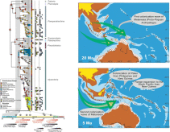

## [Molecular Phylogenetics and Evolution](https://www.sciencedirect.com/science/journal/10557903)

[Volume 123](https://www.sciencedirect.com/science/journal/10557903/123/supp/C), June 2018, Pages 16-25

# An ant genus-group (*Prenolepis*) illuminates the biogeography and drivers of insect diversification in the Indo-Pacific

[PávelMatos-Maraví<sup>a</sup><sup>b</sup><sup>c</sup><sup>d</sup>](https://www.sciencedirect.com/science/article/pii/S1055790316303414#!)[Ronald M.Clouse<sup>e</sup>](https://www.sciencedirect.com/science/article/pii/S1055790316303414#!)[Eli M.Sarnat<sup>f</sup>](https://www.sciencedirect.com/science/article/pii/S1055790316303414#!)[Evan P.Economo<sup>g</sup>](https://www.sciencedirect.com/science/article/pii/S1055790316303414#!)[John S.LaPolla<sup>h</sup>](https://www.sciencedirect.com/science/article/pii/S1055790316303414#!)[MichaelaBorovanska<sup>a</sup>](https://www.sciencedirect.com/science/article/pii/S1055790316303414#!)[ChristianRabeling<sup>i</sup><sup>l</sup>](https://www.sciencedirect.com/science/article/pii/S1055790316303414#!)[JesseCzekanski-Moir<sup>j</sup>](https://www.sciencedirect.com/science/article/pii/S1055790316303414#!)[FransinaLatumahina<sup>k</sup>](https://www.sciencedirect.com/science/article/pii/S1055790316303414#!)[Edward O.Wilson<sup>l</sup>](https://www.sciencedirect.com/science/article/pii/S1055790316303414#!)[MilanJanda<sup>a</sup><sup>m</sup>](https://www.sciencedirect.com/science/article/pii/S1055790316303414#!)

https://doi.org/10.1016/j.ympev.2018.02.007[Get rights and content](https://s100.copyright.com/AppDispatchServlet?publisherName=ELS&contentID=S1055790316303414&orderBeanReset=true)

## Highlights

**•**

Faunal interchange between Asia and Australia has been an ancient zoogeographical event (20–25 Ma).

**•**

New Guinea was colonized by Miocene ants along its northern edge (proto-Papuan archipelago).

**•**

Ancient dispersal conduit (Vitiaz Arc) crossing Melanesia might have existed at ca. 15–10 Ma.

**•**

Habitat preference shifts from tropical rainforest to disturbed environment have been inferred.

**•**

Such shifts may have favored geographical range expansions and [phylogenetic](https://www.sciencedirect.com/topics/biochemistry-genetics-and-molecular-biology/phylogeny) diversification.

## Abstract

The Malay Archipelago and the tropical South Pacific (hereafter the Indo-Pacific region) are considered biodiversity hotspots, yet a general understanding of the origins and diversification of species-rich groups in the region remains elusive. We aimed to test hypotheses for the evolutionary processes driving insect species diversity in the Indo-Pacific using a higher-level and comprehensive phylogenetic hypothesis for an ant clade consisting of seven genera. We estimated divergence times and reconstructed the biogeographical history of ant species in the *Prenolepis* genus-group (Formicidae: Formicinae: Lasiini). We used a fossil-calibrated phylogeny to infer ancestral geographical ranges utilizing a biogeographic model that includes founder-event speciation. Ancestral state reconstructions of the ants' ecological preferences, and diversification rates were estimated for selected Indo-Pacific clades. Overall, we report that faunal interchange between Asia and Australia has occurred since at least 20–25 Ma, and early dispersal to the Fijian Basin happened during the early and mid-Miocene (ca. 10–20 Ma). Differences in diversification rates across Indo-Pacific clades may be related to ecological preference breadth, which in turn may have facilitated geographical range expansions. Ancient dispersal routes suggested by our results agree with the palaeogeography of the region. For this particular group of ants, the rapid orogenesis in New Guinea and possibly subsequent ecological shifts may have promoted their rapid diversification and widespread distribution across the Indo-Pacific.

## Graphical abstract

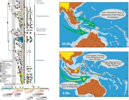

## Keywords

Biogeography

Diversification rate

Ecological shift

New Guinea

Pacific islands

Taxon cycle

## 1. Introduction

The islands of the Pacific Ocean constitute a relatively small amount of land area, but they harbour an extraordinary number of endemic taxa (Keppel et al., 2009). Given the complexity of their biogeographical history, multiple scenarios for the origin of the region's vast diversity have been proposed (Gillespie et al., 2008; Keppel et al., 2009; Lohman et al., 2011; Stoddart, 1992), but evaluations of them incorporating robust [phylogenetic](https://www.sciencedirect.com/topics/biochemistry-genetics-and-molecular-biology/phylogeny) inferences, probabilistic biogeography analyses, and ecological data have been scarce, especially as applied to species-rich groups (but see Gressitt, 1984; de Boer & Duffels, 1996; Sharma & Giribet, 2012; Clouse et al., 2015; Economo et al., 2015b). In this study, we aim to understand the evolution of the ants within the *Prenolepis* genus-group (Formicinae: Lasiini) (LaPolla et al., 2010a; Ward et al., 2016) as a model for studying historical biogeography in the Malay Archipelago and the tropical South Pacific (hereafter the TSP; Fig. 1). These ants are geographically widespread, and their lineages exhibit a broad array of ecological preferences. They are a ubiquitous component of tropical forests, they occupy all types of terrestrial habitats in the region, and some species have become invasive.

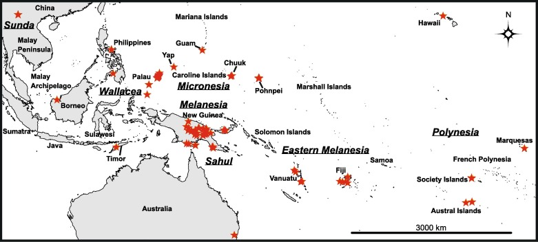

Fig. 1. Map of the Indo-Pacific region. Red stars represent this study's sampling localities. Locality information including GPS coordinates, elevation, and brief habitat descriptions are presented in Table A.1 in Appendix A.

Although various palaeogeographical reconstructions have been proposed for the region (Baldwin et al., 2012; Hall, 2013; Lohman et al., 2011), most models agree that there was a significant rise of subaerial (above water) land and orogenic activity within the past 5–10 Ma. However, it is unclear whether there was ever a chain of volcanic activity and possible archipelago connecting the Sunda Shelf in Southeast (SE) Asia and the Sahul Shelf, which includes Australia and New Guinea (Hall, 2013; Lohman et al., 2011). If such a gateway did not exist, then dispersal of many non-marine taxa between Asia and Australia across Wallace’s Line and the Wallacea region (the islands between Borneo and New Guinea) would have been limited during most of the Miocene (i.e., 10–25 Ma); however dated [molecular phylogenies](https://www.sciencedirect.com/topics/biochemistry-genetics-and-molecular-biology/molecular-phylogeny) of several [vertebrate](https://www.sciencedirect.com/topics/agricultural-and-biological-sciences/vertebrates) groups strongly suggest faunal interchange across Wallacea throughout the Miocene epoch (Cibois et al., 2014; Georges et al., 2014; Jønsson et al., 2011; Mitchell et al., 2014). Molecular chronograms of insect taxa, nonetheless, largely agree with a later biotic exchange scenario, around the late Miocene and Pliocene (i.e., <15 Ma; Balke et al., 2007; Condamine et al., 2013, Condamine et al., 2015; Müller et al., 2013; Tänzler et al., 2014; but see, Economo et al., 2015b), but even among arthropods there are unexplained dispersal patterns (Clouse and Giribet, 2007). Not only is the existence of such a Miocene land bridge unclear, but so is its possible extent, location, and duration.

The island of New Guinea is a major centre of biotic endemism in the region. It is believed that arthropod diversification there has occurred since the early Miocene (ca. 20–25 Ma; de Boer & Duffels, 1996; Sharma & Giribet, 2012; Müller et al., 2013), accelerating during the past 5–10 Ma, concurrent with the orogeny of its Central Range (Toussaint et al., 2014). Although the tectonic history of New Guinea is complex (Baldwin et al., 2012), broadly speaking there are two competing hypotheses for the emergence of its land: (1) an early Miocene islands group along the northern edge, so-called the proto-Papuan archipelago (Hall, 2002; Jønsson et al., 2011; Lohman et al., 2011), and alternatively, (2) an Oligocene Papuan peninsular orogeny (ca. 30–35 Ma) restricted to southeastern New Guinea (van Ufford and Cloos, 2005). These two models make contrasting predictions about the first colonization events of New Guinea as either taking place on the northern or southeastern sides of the island.

In the case of oceanic islands, it was hypothesized that most of the extant TSP archipelagos emerged during the late Miocene and Pliocene (ca. 5–10 Ma; Gillespie et al., 2008; Gillespie & Clague, 2009), but volcanic activity has been reconstructed since at least the Oligocene (ca. 30 Ma) (Neall and Trewick, 2008). Although palaeogeographic reconstructions depict ancient Melanesian volcanic arcs extending from New Guinea into the Fijian Basin (Hall, 2002), subaerial land may have been ephemeral (Hall, 2013). One hypothesis, the Vitiaz Arc Model, suggests a relatively continuous archipelago extending throughout proto-Papua, the Solomon Islands, Vanuatu and Fiji (Ewart, 1988; Rodda, 1994). Biogeographically, this scenario predicts early stepping-stone dispersals to the southwest Pacific, which may have occurred until the disruption of the island arc at about 10 Ma (Hall, 2002). Some of these earlier colonizers might never have faced extinction because certain islands in Vanuatu and Fiji remained subaerial since the early Miocene (ca. 25 Ma; Sarnat & Economo, 2012). In fact, time-calibrated insect phylogenies strongly support the idea of a mid-Miocene colonization of Fiji from either New Guinea or SE Asia (Balke et al., 2007; Economo et al., 2015a; Lucky and Sarnat, 2010; Sarnat and Moreau, 2011).

Apart from the geological processes that might have facilitated the colonization of Melanesia, including New Guinea, and the TSP, species diversification and distribution across islands may have been driven locally by ecological processes, as suggested by recent advances in Island Biogeography theory (Whittaker et al., 2008). The expansion/contraction phases, or the taxon cycle hypothesis, is a classic, influential model that attempts to explain population differentiation and geographic ranges over time in an ecological framework (Ricklefs and Cox, 1972; Wilson, 1961, Wilson, 1959). In the expansion stage of the cycle, species colonize nearby archipelagos (geographical expansion) facilitated by shifts in habitat preference towards marginal habitats such as island coasts (ecological expansion). The following contraction stages involve phenotypic and [genetic differentiation](https://www.sciencedirect.com/topics/agricultural-and-biological-sciences/genetic-divergence) of populations across islands, extinction of small unspecialized populations, and the origin of single-island endemics. Although biogeographic data and phylogenetic evidence have partially given support to the taxon cycles (Economo et al., 2015b; Economo and Sarnat, 2012; Jønsson et al., 2014; Ricklefs and Bermingham, 2002), the complexity of the hypothesis has hindered its comprehensive evaluation. For instance, other factors have been proposed to explain species' expansion and contraction phases, such as recent climatic fluctuations, character-displacement, and disparate dispersal abilities across lineages (e.g., Pregill & Olson, 1981; Liebherr & Hajek, 1990; Losos, 1992).

Phylogenetically, the taxon cycle hypothesis predicts the repeated evolution of widespread lineages exhibiting ecological shifts (Ricklefs and Cox, 1972). Lineages in the expansion phase could give rise to daughter lineages adapted to marginal habitats, thus, the expansion phase may also be represented by entire clades having wider ecological preferences. However, a potential link between the expansion phase and phylogenetic diversification of Melanesian insects remains to be tested (but see, Sarnat & Moreau, 2011; Economo & Sarnat, 2012; Economo et al., 2015b). If expansion phases and phylogenetic diversification are indeed correlated, we would expect increased diversification rates within certain clades due to expanded ecological opportunities.

In this study, we test four pairs of competing hypotheses that collectively inform our understanding of diversity dynamics in the Indo-Pacific region:

**1.**

Asia-Australia dispersal in the Miocene

**(a)**

Dispersal between SE Asia and Australia was mostly post-late Miocene due to a lack of subaerial land before 5–10 Ma.

**(b)**

Older colonization events of terrestrial lineages between these two areas were possible since at least the early Miocene, either through overwater dispersal or via significant emergent land not accounted for by the current palaeogeographic reconstructions.

**2.**

Colonization of New Guinea

**(a)**

The first colonization of—and diversification in—New Guinea was in a proto-Papuan archipelago on the northern edge of the island.

**(b)**

The first emergence, colonization, and diversification in New Guinea occurred in the present-day Papuan peninsula on the southeastern part of the island.

**3.**

Colonization of East Melanesia

**(a)**

Ancient colonization of east Melanesia (Vanuatu and Fiji) was facilitated by the hypothesized ancient island chain associated with the Vitiaz arc, which may have lasted until about 10 Ma.

**(b)**

Colonization of Vanuatu and Fiji occurred during the Pliocene (< 5 Ma) as a consequence of substantial emergence of land above sea.

**4.**

Range expansion, shifts in ecological preference, and radiation

**(a)**

Lineages go through concordant shifts in ecological preference and geographical range expansion, which may result in increased phylogenetic diversification rates.

**(b)**

Range expansions are not linked to niche shifts, and diversification remains constant over time, thus, the [extant species](https://www.sciencedirect.com/topics/biochemistry-genetics-and-molecular-biology/extant-species) diversity in the region is time-dependent (i.e., older clades contain more species diversity).

To test these hypotheses, we reconstruct a dated molecular phylogeny of seven ant genera in the *Prenolepis* genus-group, calibrated using fossil data and secondary constraint, and infer its ancestral geographical ranges, habitat preferences, and diversification rates on species-rich Indo-Pacific clades.

## 2. Material and methods

### 2.1. Sample and dataset acquisition

The *Prenolepis* genus-group is monophyletic (Blaimer et al., 2015; LaPolla et al., 2010a) and has recently been classified within the tribe Lasiini based on [phylogenomic](https://www.sciencedirect.com/topics/biochemistry-genetics-and-molecular-biology/phylogenomics) data (Ward et al., 2016). The group has a worldwide distribution, occurring mostly in tropical and subtropical regions. In the Malay Archipelago, TSP, and Australia, the focal study area, the group consists of 35 described species (AntWeb, 2016). We collected ants throughout the study region over a 10 year period to obtain the most geographically and taxonomically extensive sampling of species as possible, including undescribed and cryptic diversity. We sampled ca. 470 specimens that represent 73 putative species distributed across our focal study area (Fig. 1; Table A.1 in Appendix A). For most of these specimens (91%; see Table A.1), we sequenced the barcoding region (659 bp) of the mitochondrial COI gene. Furthermore, for the [phylogenetic](https://www.sciencedirect.com/topics/biochemistry-genetics-and-molecular-biology/phylogeny) analyses, we expanded the molecular dataset for selected specimens to include at least one specimen per species. This expanded aligned dataset consists of 3389 bp from six protein-coding genes: one mitochondrial (COI) and five nuclear gene markers (CAD, EF-1αF1, EF-1αF2, LWR, and wingless). We retrieved sequences from GenBank of outgroup taxa (tribe Lasiini: *Cladomyrma*, *[Lasius](https://www.sciencedirect.com/topics/biochemistry-genetics-and-molecular-biology/lasius)*, *Myrmecocystus*) (Ward et al., 2016) and all available sequences for 63 taxa within the *Prenolepis* genus-group distributed around the world. All voucher specimens were deposited in the Melanesian Ant Collection, Biology Centre of the Czech Academy of Sciences, with selected duplicates deposited in the MCZ (Museum of Comparative Zoology, Cambridge, MA, USA).

Species determination was primarily based on morphology, whereas molecular divergences were used to evaluate putative species boundaries and to detect cryptic species with substantial [genetic variation](https://www.sciencedirect.com/topics/agricultural-and-biological-sciences/genetic-divergence). We used the program bPTP (Zhang et al., 2013) to delimit species based on branch length information. The multi-species coalescent model could not be utilized because of computational limitations, convergence and mixing problems when analyzing our dataset consisting of multiple genera (analyses not shown) (Yang and Rannala, 2010). However, the species assignments by bPTP and programs based on the multi-species coalescent, such as BP&P, may be similar in some cases (Toussaint et al., 2015). As input for the program bPTP, we used a maximum likelihood tree with branch lengths representing number of substitutions as inferred by RAxML v8.0 (Stamatakis, 2014). We used a multi-locus dataset, with 164 ingroup specimens having unique COI haplotypes and at least one nuclear marker sequenced. The molecular species delimitation analysis was conducted through the bPTP web server (http://species.h-its.org/ptp/), having the following settings: 500,000 MCMC generations; thinning by a factor of 100; and 25% burnin.

### 2.2. Phylogenetic analyses

Ingroup members of our molecular dataset consisted of *Prenolepis* genus-group specimens from our focal study area and other regions in the world, and included in total 176 specimens from 124 species, having at least 4 out of 6 gene fragments sequenced (level of matrix completeness ca. 90%). Based on Bayes factors calculated by the stepping-stone sampling approach in MrBayes v3.2.2 (Ronquist et al., 2012), we used the best-fit partitioning strategy consisting of by-gene and by-coding positions in all phylogenetic analyses (21 partitions; Table A.2 in Appendix A). Other less-fit partitioning schemes that were analyzed include: (a) all sequences concatenated (1 partition), (b) mitochondrial and nuclear sequences (2 partitions), (c) each gene marker (7 partitions), and (d) nucleotide sites grouped in bins with comparable relative evolutionary rates as estimated by the program TIGER (Cummins and McInerney, 2011) (3 partitions), after verifying congruence among single-gene tree topologies (Fig. A.4 in Appendix A).

Maximum likelihood analysis was conducted using RAxML v8.0 as implemented in CIPRES (Miller et al., 2010). We performed “rapid bootstrapping” with 1000 iterations to assess the level of node support. Bayesian inferences were conducted using MrBayes v3.2.2, with two independent runs, each for 50 million generations with sampling every 5000 generations. We applied the mixed option for nucleotide substitution (Huelsenbeck et al., 2004) to each partition and a conservative burnin of 25%. We verified that the final average standard deviation split frequencies were lower than 0.05, PSRF values were approaching unity, and log-likelihoods reached a stationary distribution.

### 2.3. Molecular dating of phylogenies

Divergence dates were obtained under the uncorrelated relaxed-clock model as implemented in BEAST v2.3.1 (Bouckaert et al., 2014), using a reduced dataset comprising one specimen per species. The level of completeness of this molecular dataset is nearly 85%. We calibrated the phylogeny using three extinct *Prenolepis*-group species with affinities to three extant genera (*Nylanderia*, *Prenolepis*, and *Pseudolasius*) found in [Baltic amber](https://www.sciencedirect.com/topics/agricultural-and-biological-sciences/baltic-amber) (34–42 Ma) and two [extinct species](https://www.sciencedirect.com/topics/biochemistry-genetics-and-molecular-biology/extinct-species) within the extant genera *Nylanderia* and *Zatania* from [Dominican amber](https://www.sciencedirect.com/topics/agricultural-and-biological-sciences/dominican-amber) (15–20 Ma) (LaPolla et al., 2012; LaPolla and Dlussky, 2010) (see Appendix A for further details on fossil taxa phylogenetic placement). Because the Baltic fossils cannot be confidently assigned to any extant infrageneric group or clade, we conservatively constrained the stem ages of *Nylanderia*, *Prenolepis*, and *Pseudolasius* using an exponential distribution with mean of 5.0 and offset to 34.0. The Dominican fossils, instead, closely resemble extant clades and are likely members of crown groups (LaPolla et al., 2012; LaPolla and Dlussky, 2010). Therefore we constrained the minimum crown ages of *Zatania* and the North American *Nylanderia parvula* clade following an exponential distribution with mean of 3.0 and offset to 15.0. In addition, we also constrained the stem of the genus *Lasius* (outgroup) based on fossil data from Baltic amber deposits, following the same calibration parameters as above. A secondary calibration point was used to constrain the root of the tree (i.e., the tribe Lasiini), by setting a broad normal distribution to the root height with mean of 77.4 Ma (5% quantiles to 66.5 Ma and 88.3 Ma), following Blaimer et al., (2015).

We selected the Birth-Death Model as the tree prior (Stadler, 2009), and substitution models were unlinked across partitions. The best substitution models for each gene partition were calculated using jModelTest 0.1.1 (Posada, 2008) under the Bayesian Information Criterion: GTR+Γ model for CAD; HKY+Γ model for EF-1αF1; SYM+Γ model for EF-1αF2; GTR+Γ model for COI; GTR+Γ model for LWR; and SYM+Γ model for wingless. We ran the analyses using four independent runs for 100 million generations each, sampling every 5000 generations. We checked that ESS values were higher than 200 before combining and summarizing the estimated trees (Fig. 2, Fig. 3). An additional analysis using the Yule tree model is presented in Fig. A.5 in Appendix A.

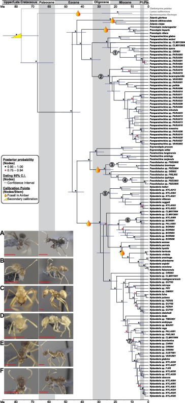

Fig. 2. Time-calibrated phylogeny of the *Prenolepis* genus-group and outgroup taxa (in grey) as inferred in BEAST. Six fossil-based calibration points were used as minimum ages for crown (*Zatania*, *Nylanderia parvula* group) or stem groups (*[Lasius](https://www.sciencedirect.com/topics/biochemistry-genetics-and-molecular-biology/lasius)*, *Prenolepis*, *Pseudolasius*, *Nylanderia*), based on morphological affinities or apomorphies sharing with close taxa (LaPolla and Dlussky, 2010). A secondary calibration from (Blaimer et al., 2015) was used for the root of the tree (tribe Lasiini). Posterior probabilities of each node are depicted as coloured asterisks (black for > 0.95; red for 0.75–0.94; values < 0.75 are not shown). 95% credibility intervals for divergence times are displayed over each node in the tree. The seven main Indo-Pacific clades within the *Prenolepis* genus-group are numbered in the phylogeny. Scale bar in Ma. Inset, specimen photographs in frontal and lateral views. Red scale bar in each photograph represents 1 mm. A: *Paraparatrechina opaca* (MJ15399, New Guinea); B: *Paraparatrechina* sp. VANU002 (CR120619-01–02, Vanuatu); C: *Pseudolasius* sp. PSEU002 (MJ9384, New Guinea); D: *Pseudolasius* sp. PSEU005 (MJ16068, New Guinea); E: *Nylanderia nuggeti* (MJ6887, New Guinea); F: *Nylanderia* *vaga* (MJ16124, Fiji).

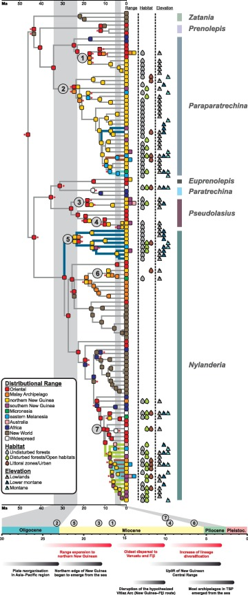

Fig. 3. Time-calibrated phylogeny of the Indo-Pacific *Prenolepis* shown in Fig. 2. Squares over nodes and terminals in the phylogeny represent inferred and extant geographical ranges, respectively. Coloured symbols depicts the recorded habitat preference (leaf shape) and elevation of each Indo-Pacific species (mountain shape). One or two most probable ancestral geographical ranges estimated in BioGeoBEARS under the DEC + J model are depicted over each node; red asterisks represent ranges with probabilities between 0.1 and 0.5, whereas ranges with probabilities < 0.1 are not considered. Ancestral state reconstruction of habitat and elevation preferences using Mesquite on each Indo-Pacific clade, are displayed as coloured branches. The median ages of clades 1–7 (gray circles), main biogeographical events (red bars), and main geological events (black bars), are each depicted below the phylogeny. Scale bar in Ma.

### 2.4. Biogeographical inferences

We estimated ancestral geographic ranges to test the competing pairs of Hypotheses 1–3 on the origin of New Guinean, Melanesian and TSP ant diversity (i.e., first faunal interchange between SE Asia and Australia, and colonization events to New Guinea, Vanuatu, and Fiji). Although the New World and the Afrotropics were considerably undersampled, it is probable based on morphological similarities (Kallal and LaPolla, 2012; LaPolla et al., 2011a, LaPolla et al., 2011b; LaPolla et al., 2010a, LaPolla et al., 2010b) and global framework phylogenies (Blaimer et al., 2015; LaPolla et al., 2010a) that such missing taxa would cluster along the well-defined, geographically correspondent clades (Fig. 2, Fig. 3; see Appendix A for further accounts on morphology and distribution of missing taxa). [Geographical distributions](https://www.sciencedirect.com/topics/agricultural-and-biological-sciences/geographical-distribution) of species were taken from the literature and public databases (e.g., Clouse, 2007; Economo & Sarnat, 2012; Antweb, 2016), as well as from our field records (http://www.newguineants.org).

Ancestral geographic ranges were estimated following the Dispersal-Extinction-Cladogenesis model (Ree et al., 2005) and including a founder-event speciation parameter (DEC + J; Matzke, 2014). We conducted our biogeographical analyses by finely subdividing the focal region based on biogeographical characteristics of Pacific fauna (Fig. 1; Keppel et al., 2009), resulting in a total of nine global geographical areas. The palaeogeographic models of the Indo-Pacific (Gillespie and Clague, 2009; Hall, 2013, Hall, 2002) were incorporated as differential rates of dispersal (range expansion) across a time-stratified phylogeny at 25, 15, and 5 Ma. Relative dispersal rates between two areas were arbitrarily set from 1.0 to 10<sup>−4</sup> as an attempt to represent the extent of geographic barriers such as sea straits and mountain ranges (see Appendix A for further details). The analyses were performed on a likelihood framework using the R package BioGeoBEARS (Matzke, 2013). Further analyses using other biogeographical models, including the DIVA-LIKE and BAYAREA-LIKE, are described in Appendix A but in all cases the DEC + J model outperformed other biogeographical models (Akaike weight = 0.998, Table 1).

|  | LnL | numparams | d | e | j | AICc | Akaike weights |
| --- | --- | --- | --- | --- | --- | --- | --- |
| DEC + J ** | −298.42 | 3 | 0.026 | 0.003 | 0.246 | 602.84 | 0.99845 |
| DIVA-LIKE + J | −304.89 | 3 | 0.029 | 0.002 | 0.252 | 615.79 | 0.00154 |
| BAYAREA-LIKE + J | −311.57 | 3 | 0.026 | 0.004 | 0.241 | 629.14 | 0.00000 |
| DEC | −328.26 | 2 | 0.041 | 0.009 | – | 660.51 | 0.00000 |
| DIVA-LIKE | −333.74 | 2 | 0.046 | 0.007 | – | 671.49 | 0.00000 |
| BAYAREA-LIKE | −364.74 | 2 | 0.044 | 0.046 | – | 733.48 | 0.00000 |

### 2.5. Reconstruction of ancestral habitat preferences and diversification rates

We reconstructed ancestral ecological preferences of Indo-Pacific clades to evaluate any association between niche shift and geographical range expansion (competing pair of Hypotheses 4a–b). We compiled habitat preferences for each species from the literature (e.g., Clouse, 2007; Economo & Sarnat, 2012; Antweb, 2016) and our field records (http://www.newguineants.org). Locality information for each collected specimen, including habitat type and GPS coordinates, are presented in Appendix A, Table A.1, and each species' distributional information can be found in Table A.4 and in the New Guinea Ants database (http://www.newguineants.org). Three categories were set for the “habitat” character: (1) undisturbed primary rainforest, (2) disturbed forest and [savanna](https://www.sciencedirect.com/topics/agricultural-and-biological-sciences/savannas), (3) highly-disturbed areas including gardens, docks, coastal margins and urban areas; and “elevation” was categorized as: (1) lowlands, (2) lower montane, and (3) montane. The breaks between the three elevation categories were at 800 m and 1600 m on New Guinea, and at 250 m and 500 m on TSP archipelagos, based on major distributional turnover (pers. obs.; Sarnat & Economo, 2012). Character matrices were used to reconstruct and trace ancestral states over the phylogeny, under the Fitch Parsimony (unordered) model and the Mk1 Likelihood model, in Mesquite 3.10 (Maddison and Maddison, 2016).

To test for expanding geographic ranges and ecological opportunity driving diversification (Hypothesis 4a), we estimated the diversification rates of four Indo-Pacific clades, two within *Paraparatrechina* and two within *Nylanderia*. We used the branching times of these Indo-Pacific lineages to evaluate the best-fitting diversification model using the R package DDD (Etienne et al., 2012). We carried out the three following analyses: (1) constant pure-birth diversification (Yule), (2) constant birth-death diversification (BD), and (3) diversity-dependence birth-death diversification, with speciation linearly declining with diversity (DD). Akaike weights were used to estimate the relative probability of each diversification model fitting our dataset. Diversification rates were compared across clades to evaluate the alternative scenarios of increased rates followed by diversity-dependent speciation, potentially linked to ecological shifts (Hypothesis 4a) vs. constant phylogenetic diversification (Hypothesis 4b).

## 3. Results

### 3.1. Species delimitation and phylogenetic relationships

The estimated number of species recovered by bPTP ranged between 80 and 105, with a mean of 92 species (Fig. A.1). Most of the species boundaries were moderately to highly supported (Bayesian supporting values > 0.8), and only nine species were not in agreement with our morphologically-based sorting. Five of these conflicting lineages, however, represented described species whose morphological identifications were based on available [taxonomic keys](https://www.sciencedirect.com/topics/agricultural-and-biological-sciences/taxonomic-keys) and comparisons with museum specimens. In cases where there was no sufficient molecular evidence or conflicting resolutions of molecular species boundaries, we followed our morphologically-based species delimitations (see Fig. A.1 for a visual inspection of molecular divergences within these conflicting lineages). Nonetheless, the species diversity estimated in this study should be taken as preliminary, and a thorough taxonomic investigation and the usage of multi-species coalescent on smaller taxonomic groups are strongly demanded, whereas other fast-evolving molecular markers (e.g., STRs) along with better population sampling may be beneficial in finding any further cryptic species not detected here.

The monophyly of each genus and putative species with more than two individuals sampled was strongly supported in every [phylogenetic analysis](https://www.sciencedirect.com/topics/biochemistry-genetics-and-molecular-biology/phylogeny) (Fig. 2 and Figs A.2–A.4). All Melanesian (which includes New Guinea), Australian, and TSP lineages clustered together in monophyletic groups and closely related to SE Asian lineages. New World and African species were recovered in separate clades, and apparently these geographical regions have not directly contributed to the extant Melanesian ant fauna. We identified seven highly-supported Melanesian and TSP clades (Fig. 2, Fig. 3; posterior probabilities [PP] ≥ 0.95, bootstraps ≥ 90%): two clades within *Paraparatrechina* and *Pseudolasius*, and three clades within *Nylanderia*.

### 3.2. Divergence times

The crown age of the *Prenolepis* genus-group was estimated at 46.0 Ma (95% HPD 41.2–51.8 Ma). Ingroup divergence times and tree topologies were similar and consistently recovered across independent analyses using distinct tree priors (Birth-Death and Yule) (Fig. A.5). Moreover, our estimated timing of origin and diversification of the *Prenolepis* genus-group is in line with Blaimer et al. (2015), who found that the group originated and began its diversification by the late Paleocene and Eocene (i.e., about 45–60 Ma). The extant Melanesian lineages arrived to the region and diversified as early as 23.5 Ma (95% HPD 19.4–27.9 Ma) (i.e., the crown age of clade 2 within *Paraparatrechina*), but it is likely that the actual dispersal event may have been earlier but probably not before 34.1 Ma (95% HPD 28.9–39.6 Ma), which represents the stem age of clade 2 in our phylogeny.

### 3.3. Ancestral state reconstructions and diversification rates

A continental origin from Asia was reconstructed for all the Melanesian *Prenolepis* genus-group lineages (Fig. 3). Geographic range expansions occurred during two main instances: at the early Miocene (ca. 20–25 Ma) from SE Asia to New Guinea, and during the late Miocene and Plio-Pleistocene (ca. 3–10 Ma), again from SE Asia to Melanesia, but also from the latter region towards the remaining of Indo-Pacific islands (Fig. 4). The DEC + J biogeographical model fits our [molecular phylogeny](https://www.sciencedirect.com/topics/biochemistry-genetics-and-molecular-biology/molecular-phylogeny) better than others, such as BAYAREA-LIKE or DIVA-LIKE (Table 1).

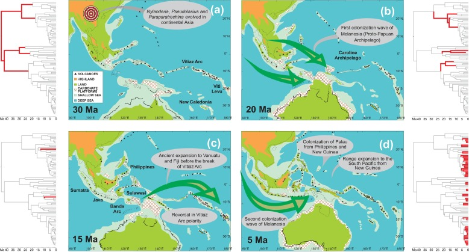

Fig. 4. Palaeogeographic maps and evolutionary history of the *Prenolepis* genus-group in the Indo-Pacific. Panels a–d depict the four time slices used in biogeographical analyses. The legend in panel a describes the distribution of land and sea for all maps, whereas major dispersal events are shown as green arrows. Maps were

adapted from Hall (2013)

Ancestral state reconstructions suggested that undisturbed (primary) rainforest was the most likely habitat preferred by the common ancestor of three main Indo-Pacific clades (within *Paraparatrechina* and *Nylanderia*). However, highly-disturbed and open-environments were recovered as the most-likely ancestral state in clade 7 (within *Nylanderia*) with about 0.67 marginal probability, and within clade 2 (*Paraparatrechina*) with about 0.5 marginal probability. On the other hand, the origin and evolution of clade 5 (within *Nylanderia*) is likely linked to lower montane habitats on New Guinea (marginal probability of 0.97). At about 10 Ma, there was a shift in habitat preference from [lowland](https://www.sciencedirect.com/topics/agricultural-and-biological-sciences/lowlands) to montane environments in clade 2 with marginal probabilities of more than 0.6. The colonization of montane areas in archipelagos of the TSP occurred recently and simultaneously with the shift to disturbed environments within clades 2 and 7 (< 5.0 Ma).

The evolution of the smaller clades 1 and 5 (within *Paraparatrechina* and *Nylanderia*, respectively) might be explained by two equally-probable diversification models, the constant-rate or the diversity-dependence scenarios. The best-fit diversification model for the larger clades 2 and 7, however, was the diversity-dependence model (Akaike weights > 0.99). Estimated diversification rates for the small clades varied between 0.06 and 0.17, whereas the diversification rates for clade 2 was 0.26, for the *P*. *oceanica*–*P*. *minutula* subclade within clade 2 was 0.5, and for clade 7 was 0.61 (Table 2).

Table 2. [Phylogenetic](https://www.sciencedirect.com/topics/biochemistry-genetics-and-molecular-biology/phylogeny) diversification analyses on selected Indo-Pacific clades using DDD and the median divergences times in the chronogram inferred by BEAST. Estimated parameters: number of parameters in each model (nP), net diversification rate (*r*) = speciation minus extinction rates, clade-level carrying capacity (*K*) in diversity-dependence model, maximum likelihood of the model (LogLik), Akaike Information Criterion (AIC), Akaike weights (A.W.) for each diversification scheme. The most probable model fitting the dataset is shown in asterisks (**). Yule: pure-birth diversification, (BD) constant birth-death diversification, (DD) diversity-dependent diversification.

| *Clade 1 (P. opaca clade)* | nP | *r* | *K* | LogLik | AIC | A.W. |
| --- | --- | --- | --- | --- | --- | --- |
| Yule | 1 | 0.072 | – | −23.304 | 48.609 | 0.530 |
| BD | 2 | 0.072 | – | −23.305 | 50.609 | 0.195 |
| DD | 2 | 0.128 | 20 | −22.961 | 49.922 | 0.275 |
| *Clade 2 (P. oceanica–P. pallida clade)* |  |  |  |  |  |  |
| Yule | 1 | 0.084 | – | −83.608 | 169.216 | 0.003 |
| BD | 2 | 0.084 | – | −83.608 | 171.216 | 0.001 |
| DD** | 2 | 0.259 | 66 | −76.812 | 157.623 | 0.996 |
| *Clade 2, (P.oceanica*–*P. minutula* subclade) |  |  |  |  |  |  |
| Yule | 1 | 0.108 | – | −51.925 | 105.851 | 0.000 |
| BD | 2 | 0.108 | – | −51.925 | 107.851 | 0.000 |
| DD** | 2 | 0.502 | 38 | −42.681 | 89.363 | 1.000 |
| *Clade 5 (N. nuggeti clade)* |  |  |  |  |  |  |
| Yule | 1 | 0.063 | – | −24.200 | 50.399 | 0.395 |
| BD | 2 | 0.063 | – | −24.200 | 52.400 | 0.145 |
| DD | 2 | 0.170 | 15 | −23.048 | 50.097 | 0.460 |
| *Clade 7 (N. obscura clade)* |  |  |  |  |  |  |
| Yule | 1 | 0.157 | – | −59.661 | 121.322 | 0.000 |
| BD | 2 | 0.157 | – | −59.661 | 123.322 | 0.000 |
| DD** | 2 | 0.613 | 35 | −50.165 | 104.330 | 1.000 |

## 4. Discussion

Ants in the *Prenolepis* genus-group likely colonized New Guinea from continental SE Asia in the early Miocene ca. 25 Ma. Dispersal to eastern Melanesia (Fiji and Vanuatu) is as old as 10–20 Ma, suggesting that a subaerial island chain associated with the Vitiaz Arc may have facilitated the colonization of these archipelagos during the Miocene. Substantially larger diversification rates in the young and diverse clade 7 (within *Nylanderia*), and to a lesser extent in clade 2 (within *Paraparatrechina*), may have been linked to expansions in both ecological preference and geographical range. Therefore, it may be possible that ecological processes have significantly shaped the ant diversity and distribution in Melanesia, as partially suggested by the taxon cycle hypothesis.

### 4.1. The timing of faunal interchange between SE Asia and Melanesia

Our results support the hypothesis that faunal interchange via Wallacea occurred as early as the Miocene (ca. 20–25 Ma; Hypothesis 1b), rather than after the late Miocene (Hypothesis 1a). Ancestral range inferences showed that Melanesian (including New Guinea) and TSP lineages very likely had a continental SE Asian origin, which agrees with the hypothesized [centre of origin and diversity](https://www.sciencedirect.com/topics/agricultural-and-biological-sciences/center-of-diversity) of the *Prenolepis* genus-group in continental tropical Asia (Blaimer et al., 2015; LaPolla et al., 2011a, LaPolla et al., 2011b; LaPolla et al., 2010a). Substantial subaerial land before 5–10 Ma may have arisen in Wallacea as scattered volcanic islands (Hall, 2012), which might have facilitated overwater dispersal of terrestrial arthropods in a stepping-stone fashion. But stratigraphic evidence in favour of emergent land in the region at the early Miocene is scarce (Baldwin et al., 2012; Hall, 2013; Lohman et al., 2011; Stelbrink et al., 2012; van Ufford and Cloos, 2005). However, biogeographical patterns and time-calibrated dispersal events suggest that significant faunal interchange might have occurred already by 25 Ma (Cibois et al., 2014; Georges et al., 2014; Jønsson et al., 2011; Mitchell et al., 2014), whereas it is likely that early Miocene [plant dispersal](https://www.sciencedirect.com/topics/biochemistry-genetics-and-molecular-biology/plant-dispersal) across Wallacea might have been enhanced by animals (Crayn et al., 2015).

The hypothesis that this exchange was due to the presence of significant amounts of land is strengthened by the independent dispersal events across unrelated ant clades at approximately the same period of time (i.e., 15–25 Ma; Fig. 3), regardless of [life history traits](https://www.sciencedirect.com/topics/biochemistry-genetics-and-molecular-biology/life-history-trait). For instance, ant nesting preferences across these clades vary from rotten logs, [leaf litter](https://www.sciencedirect.com/topics/agricultural-and-biological-sciences/plant-litter), to soil, and even some *Pseudolasius* appear to live completely underground (LaPolla, 2004). Our results provide further evidence that faunal interchange between Asia and Australia might be in fact an old palaeozoographic event, aided by a significant increase of land above water, in both [vertebrate](https://www.sciencedirect.com/topics/agricultural-and-biological-sciences/vertebrates) and invertebrate lineages, including other ants (Economo et al., 2015b).

### 4.2. Colonization and diversification in New Guinea

Biogeographical reconstructions of the older colonists of New Guinea supported Hypothesis 2a that the most likely region of arrival covered the Central Range and northern New Guinea (Fig. 3), rather than the southern part of the island including the Papuan peninsula (Hypothesis 2b), which in the case of the *Prenolepis* genus-group was colonized later, after the mid-Miocene (< 15 Ma). [Predaceous diving beetles](https://www.sciencedirect.com/topics/agricultural-and-biological-sciences/dytiscidae) from New Guinea have a similar pattern, though a younger timing of colonization, from a probable origin in the Central Range followed by dispersal towards the Papuan peninsula during the last 5 Ma (Toussaint et al., 2014). Although other studies found that southern Papuan lineages may be older than northern taxa (Oliver et al., 2013), these did not estimate time-calibrated species divergences thus a young origin, in the mid-Miocene or later, of these southern Papuan lineages cannot be ruled out. In this study, the model describing a proto-Papuan archipelago along the northern edge of New Guinea in the early Miocene is favoured over an old Papuan peninsular origin of extant New Guinean species diversity.

Older endemics that currently occur in montane habitats, such as the New Guinean clade 5 and certain lineages within clade 2, probably originated at about 15 Ma, in agreement with the major orogeny of the Central Range. Further sampling of montane ants along the Central Range is necessary to infer the mechanisms driving ant montane speciation in the region. For instance, ecological processes causing altitudinal segregation have been proposed as drivers of montane diversification in birds (Diamond, 1973) and ants (Economo and Sarnat, 2012; Sarnat and Economo, 2012). On the other hand, a large proportion of cladogenetic events in New Guinea occurred within northern or southern [lowland](https://www.sciencedirect.com/topics/agricultural-and-biological-sciences/lowlands) areas, and not across them as expected under a “lowland vicariant” scenario driven by the Central Range. Ecological constraints and/or geographical barriers within the northern and southern lowland areas may exist and explain the observed pattern in the *Prenolepis* genus-group, such as strong habitat associations and riverine barriers (Janda et al., 2016). Additionally, we found that on average each locality harbours 2–3 highly divergent species per genus. This may suggest that competitive exclusion of closely related species, with perhaps similar ecological niches, might be an important mechanism of ant community structure in New Guinean lowlands; a pattern described for other low-elevation ant communities (Machac et al., 2011).

### 4.3. Colonization of eastern Melanesia

The earliest insect colonization of eastern Melanesia (Vanuatu and Fiji) was estimated at about 9–17 Ma (Balke et al., 2007; Liebherr, 2005; Lucky and Sarnat, 2010; Sarnat and Moreau, 2011), consistent with the hypothesis that colonization was facilitated by emergent land as part of the subaerial Vitiaz Arc as island chain (Hypothesis 3a). In the *Prenolepis* genus-group, dispersal has occurred earlier than the recent re-exposure of land in eastern Melanesia during the Pliocene (Hypothesis 3b), whereas early Miocene land has likely remained above water and harboured older colonizers to the present. Our [phylogenetic](https://www.sciencedirect.com/topics/biochemistry-genetics-and-molecular-biology/phylogeny) reconstructions indicate that New Guinea was the likely source of ant colonists in Vanuatu and Fiji, with estimated ages congruent with previous ant chronograms (ca. 10–16 Ma; Lucky & Sarnat, 2010; Sarnat & Moreau, 2011). Dispersal to these archipelagos apparently ceased until the Plio-Pleistocene, when younger colonization events occurred at about 5 Ma, consistent with the recent re-exposure of subaerial land in the TSP. This apparent absence of dispersal during the late Miocene and early Pliocene may be expected given the disruption of the arc at about 10 Ma, when the Ontong-Java [Plateau](https://www.sciencedirect.com/topics/agricultural-and-biological-sciences/plateaus) collided with the Vitiaz trench (Ewart, 1988; Hall, 2002). However, further dated phylogenies of eastern Melanesian insects are needed to rule out other potential explanations, such as local [extinction events](https://www.sciencedirect.com/topics/agricultural-and-biological-sciences/extinction-event) that erased traces of ant dispersal between 5 and 10 Ma.

Range expansions to Micronesia and Polynesia have happened since 5 Ma, in line with the significant exposure of land in these regions during the late Miocene and Pliocene. Colonization of Palau, the richest in species diversity among Micronesian and Polynesian archipelagos (six *Prenolepis* genus-group taxa), occurred since 5 Ma from two sources: New Guinea and the Philippines. No local ant radiation has been inferred, instead, the [faunal assemblage](https://www.sciencedirect.com/topics/agricultural-and-biological-sciences/faunal-assemblage) in Palau might be the result of a long history of colonization events by unrelated lineages (Rundell, 2008). Dispersal to the Caroline Islands and to eastern Polynesia occurred geologically recently (< 4 Ma) by species with wide geographic ranges. These time-calibrated dispersal events significantly post-date the geological origins of Western Pacific archipelagos inferred since at least the mid-Miocene ca. 15 Ma (Rehman et al., 2013). [Submergence](https://www.sciencedirect.com/topics/agricultural-and-biological-sciences/submergence) of land and complete eradication of Miocene fauna by the Miocene/Pliocene transition might explain the apparent “delay” in colonization observed in our phylogeny. On the other hand, two [invasive species](https://www.sciencedirect.com/topics/biochemistry-genetics-and-molecular-biology/invasive-species), the longhorn crazy ant (*Paratrechina longicornis*) and the robust crazy ant (*Nylanderia bourbonica*) most likely spread throughout the Pacific due to commerce. In those cases, closely related COI haplotypes were recovered from distant localities, and no apparent genetic structure across islands was evident (in contrast with, for instance, *Nylanderia* *vaga*, which is similar in age and distribution; Fig. A.3).

### 4.4. The connection between niche shifts and diversification

One of the main predictions of the taxon cycle hypothesis is that range expansions may be facilitated by shifts in habitat preference, eventually resulting in ecological release whereby relaxed selective pressures caused by ecological opportunity may promote phenotypic variability and speciation. Species adapted to lowland marginal habitats, such as the coasts of islands, might be more prone to colonize other archipelagos by overwater dispersal (Hypothesis 4a). Although an explicit relationship between expansion/contraction phases and shifts in diversification rates has not been formulated, it may be possible that expanding lineages diversify due to ecological innovation through the key adaptation to marginal habitats. Using [ancestral character state](https://www.sciencedirect.com/topics/biochemistry-genetics-and-molecular-biology/plesiomorphy) reconstruction, we found that ant habitat preferences for highly disturbed and open environments may be linked to geographical expansion across archipelagos (e.g., within clade 2 and in clade 7). Moreover, adaptation to disturbed environments might also explain one of the origins of ant invasiveness, as some of the tramp species are closely related and derived from common ancestors already adapted to marginal habitats (e.g., *Nylanderia bourbonica*, *N*. *vaga*, and *N*. *obscura*, all within clade 7). In addition, alternative reproductive strategies are known to increase the invasive potential of some ant species, such as *Paratrechina longicornis* (Pearcy et al., 2011), by producing queens clonally (thelytoky) and avoiding the negative effects associated with small founding populations (Rabeling and Kronauer, 2013).

We showed that diversification scenarios facilitated by ecological innovations (shifts in habitat preference) in the Indo-Pacific region cannot be ruled out (Hypothesis 4a). Ecological opportunity in a macroevolutionary perspective might be related to an initial burst in speciation rates followed by diversity-dependent deceleration of diversification rates (Etienne and Haegeman, 2012; Rabosky, 2010). On the contrary, under a time-dependent diversification model (Yule or Birth-Death) speciation is constant, and the extant diversity across clades is primarily explained by the age of lineage’s origin (Hypothesis 4b). The diversification rates of the clade 7 (and partially within clade 2) have accelerated compared to other Indo-Pacific taxa (Table 2). This coincides with the reconstructed shift in ecological preference towards disturbed habitats (Fig. 3), which may have increased the “ecological limits” determining the clades’ species richness (Rabosky, 2009). Accordingly, shifts in habitat preference (ecological release) may not only favour geographical range expansion, as proposed by the taxon cycle hypothesis, but may also trigger species diversification of [terrestrial invertebrates](https://www.sciencedirect.com/topics/biochemistry-genetics-and-molecular-biology/terrestrial-invertebrate) in Melanesia. In this line, recent developments of island biogeography models also predict that speciation rates would peak before islands reach maximal topographic complexity, as empty niche space will provide more opportunities for radiation (Whittaker et al., 2008). However, a more rigorous approach to study macroevolutionary dynamics, including the study of ant ecology (e.g., worker abundances, dispersal abilities) and mathematical models that consider [species abundances](https://www.sciencedirect.com/topics/biochemistry-genetics-and-molecular-biology/population-abundance) (Rosindell and Phillimore, 2011) are needed before attempting a formal test of the taxon cycle in the light of [molecular phylogenies](https://www.sciencedirect.com/topics/biochemistry-genetics-and-molecular-biology/molecular-phylogeny).

## 5. Conclusions

We found evidence of old insect colonization events from SE Asia to New Guinea, dating to at least the early Miocene (ca. 25 Ma). A broad, faunistic and floristic interchange between Asia and Australia may have happened earlier than previously thought geographically possible. Moreover, early insect radiations on New Guinea have apparently occurred along the northern edge of the island, contrasting with the hypothesis of an older, subaerial Papuan peninsula. Colonization of eastern Melanesia (i.e., Vanuatu and Fiji) may be as old as 10–20 Ma, in agreement with the hypothesized ancient island chain Vitiaz Arc connecting the proto-Papuan archipelago to the Fiji Basin. In addition, a link between ecological shifts, geographic range expansion, and [phylogenetic](https://www.sciencedirect.com/topics/biochemistry-genetics-and-molecular-biology/phylogeny) diversification of insular arthropods cannot be ruled out, and such shifts may have promoted geographical range expansion and triggered diversification of the Indo-Pacific ant fauna. Further studies of other New Guinean and Melanesian insect lineages would clarify if speciation in the region is primarily driven by ecological factors, and if so, whether that is characterized by the fragmentation of geographic ranges or adaptation to new, empty niches.

## Acknowledgements

We thank David J. Lohman and two anonymous reviewers for constructive comments on previous versions of the manuscript. We are grateful to the staff of the New Guinea Binatang Research Center and to T. Pius for indispensable field assistance, to V. Novotny and S.E. Miller for assistance with our research projects, and to the Papua New Guinea Department of Environment and Conservation for assistance with research permits. We acknowledge D. Gotzek, P. Klimes, P. Krushelnycky, C. Liu, N. Plowman, K. Sagata, D. General, G. Alpert and M.D. Sorger for specimens. We thank R. Ricklefs for valuable comments, N.J. Maztke and R.S. Etienne for assisting us in the biogeographical and diversification rates analyses, and to S.O. Shattuck for help with species identifications. Funding was provided by the Czech Science Foundation (Centrum of Excellence for Tropical Biology grant; 14-36098G), Marie Curie Fellowships (Grants MARIPOSAS-704035 and PIOFGA2009-25448), Putnam Expedition Grants (Harvard Museum of Comparative Zoology), NSF (DEB-0515678; DEB-1145989; DEB-1456964), GAJU (156/2013/P; 152/2016/P), CONACYT DICB-2016 No. 282471, and UNAM PAPIIT IN206818. EPE was further supported by a subsidy funding to OIST, and CR by the Harvard Society of Fellows. Computational resources were provided by MetaCentrum (program LM2010005) and CERIT-SC, part of the Operational Program Research and Development for Innovations (CZ.1.05/3.2.00/08.0144).

## Appendix A. Supplementary data

Supplementary data 1.

Supplementary data 2.

## References

**AntWeb, 2016**

AntWeb, 2016. AntWeb. Available from <http://www.antweb.org> (Accessed August 2016).

**Baldwin et al., 2012**

S.L. Baldwin, P.G. Fitzgerald, L.E. Webb

**Tectonics of the New Guinea region**

Annu. Rev. Earth Planet. Sci., 40 (2012), pp. 495-520, 10.1146/annurev-earth-040809-152540

**Balke et al., 2007**

M. Balke, G. Wewalka, Y. Alarie, I. Ribera

**Molecular phylogeny of Pacific Island Colymbetinae: radiation of New Caledonian and Fijian species (Coleoptera, Dytiscidae)**

Zool. Scr., 36 (2007), pp. 173-200, 10.1111/j.1463-6409.2006.00265.x

**Blaimer et al., 2015**

B.B. Blaimer, S.G. Brady, T.R. Schultz, M.W. Lloyd, B.L. Fisher, P.S. Ward

**Phylogenomic methods outperform traditional multi-locus approaches in resolving deep evolutionary history: a case study of formicine ants**

BMC Evol. Biol., 15 (2015), p. 271, 10.1186/s12862-015-0552-5

**Bouckaert et al., 2014**

R. Bouckaert, J. Heled, D. Kühnert, T. Vaughan, C.-H. Wu, D. Xie, M.A. Suchard, A. Rambaut, A.J. Drummond

**BEAST 2: a software platform for Bayesian evolutionary analysis**

PLoS Comput. Biol., 10 (2014), p. e1003537, 10.1371/journal.pcbi.1003537

**Cibois et al., 2014**

A. Cibois, J.-C. Thibault, C. Bonillo, C.E. Filardi, D. Watling, E. Pasquet

**Phylogeny and biogeography of the fruit doves (Aves: Columbidae)**

Mol. Phylogenet. Evol., 70 (2014), pp. 442-453, 10.1016/j.ympev.2013.08.019

**Clouse, 2007**

R.M. Clouse

**The ants of Micronesia (Hymenoptera: Formicidae)**

Micronesica, 39 (2007), pp. 171-295

**Clouse and Giribet, 2007**

R.M. Clouse, G. Giribet

**Across Lydekker’s Line – first report of mite harvestmen (Opiliones: Cyphophthalmi: Stylocellidae) from New Guinea**

Invertebr. Syst., 21 (2007), pp. 207-227

**Clouse et al., 2015**

R.M. Clouse, M. Janda, B. Blanchard, P. Sharma, B.D. Hoffmann, A.N. Andersen, J.E. Czekanski-Moir, C. Rabeling, E.O. Wilson, E.P. Economo, E.M. Sarnat, D.M. General, G.D. Alpert, W.C. Wheeler

**Molecular phylogeny of Indo-Pacific carpenter ants (Hymenoptera: Formicidae, *Camponotus*) reveals waves of dispersal and colonization from diverse source areas**

Cladistics, 31 (2015), pp. 424-437, 10.1111/cla.12099

**Condamine et al., 2015**

F.L. Condamine, E.F.A. Toussaint, A.-L. Clamens, G. Genson, F.A.H. Sperling, G.J. Kergoat

**Deciphering the evolution of birdwing butterflies 150 years after Alfred Russel Wallace**

Sci. Rep., 5 (2015), p. 11860, 10.1038/srep11860

**Condamine et al., 2013**

F.L. Condamine, E.F.A. Toussaint, A.M. Cotton, G.S. Genson, F.A.H. Sperling, G.J. Kergoat

**Fine-scale biogeographical and temporal diversification processes of peacock swallowtails (*Papilio* subgenus *Achillides*) in the Indo-Australian Archipelago**

Cladistics, 29 (2013), pp. 88-111

**Crayn et al., 2015**

D.M. Crayn, C. Costion, M.G. Harrington

**The Sahul-Sunda floristic exchange: dated molecular phylogenies document Cenozoic intercontinental dispersal dynamics**

J. Biogeogr., 42 (2015), pp. 11-24, 10.1111/jbi.12405

**Cummins and McInerney, 2011**

C.A. Cummins, J.O. McInerney

**A method for inferring the rate of evolution of homologous characters that can potentially improve phylogenetic inference, resolve deep divergence and correct systematic biases**

Syst. Biol., 60 (2011), pp. 833-844, 10.1093/sysbio/syr064

**de Boer and Duffels, 1996**

A.J. de Boer, J.P. Duffels

**Historical biogeography of the cicadas of Wallacea, New Guinea and the West Pacific: a geotectonic explanation**

Palaeogeogr. Palaeoclimatol. Palaeoecol., 124 (1996), pp. 153-177, 10.1016/0031-0182(96)00007-7

**Diamond, 1973**

J.M. Diamond

**Distributional ecology of New Guinea birds**

Science, 179 (1973), pp. 759-769

**Economo et al., 2015a**

E.P. Economo, P. Klimov, E.M. Sarnat, B. Guénard, M.D. Weiser, B. Lecroq, L.L. Knowles

**Global phylogenetic structure of the hyperdiverse ant genus *Pheidole* reveals the repeated evolution of macroecological patterns**

Proc. R. Soc. B Biol. Sci., 282 (2015), p. 20141416, 10.1098/rspb.2014.1416

**Economo and Sarnat, 2012**

E.P. Economo, E.M. Sarnat

**Revisiting the ants of Melanesia and the taxon cycle: historical and human-mediated invasions of a tropical archipelago**

Am. Nat., 180 (2012), pp. E1-E16, 10.1086/665996

**Economo et al., 2015b**

E.P. Economo, E.M. Sarnat, M. Janda, R. Clouse, P.B. Klimov, G. Fischer, B.D. Blanchard, L.N. Ramirez, A.N. Andersen, M. Berman, B. Guénard, A. Lucky, C. Rabeling, E.O. Wilson, L.L. Knowles

**Breaking out of biogeographical modules: range expansion and taxon cycles in the hyperdiverse ant genus *Pheidole***

J. Biogeogr., 42 (2015), pp. 2289-2301, 10.1111/jbi.12592

**Etienne and Haegeman, 2012**

R.S. Etienne, B. Haegeman

**A conceptual and statistical framework for adaptive radiations with a key role for diversity dependence**

Am. Nat., 180 (2012), pp. E75-E89, 10.1086/667574

**Etienne et al., 2012**

R.S. Etienne, B. Haegeman, T. Stadler, T. Aze, P.N. Pearson, A. Purvis, A.B. Phillimore

**Diversity-dependence brings molecular phylogenies closer to agreement with the fossil record**

Proc. R. Soc. B Biol. Sci., 279 (2012), pp. 1300-1309, 10.1098/rspb.2011.1439

**Ewart, 1988**

A. Ewart

**Geological history of the Fiji – Tonga – Samoan Region of the S. W. Pacific, and Some Palaeogeographic and Biogeographic Implications**

L. Lyneborg (Ed.), The Cicadas of the Fiji, Samoa and Tonga Islands, Their Taxonomy and Biogeography, Scandinavian Science Press, Leiden, The Netherlands (1988), pp. 15-23

**Georges et al., 2014**

A. Georges, X. Zhang, P. Unmack, B.N. Reid, M. Le, W.P. McCord

**Contemporary genetic structure of an endemic freshwater turtle reflects Miocene orogenesis of New Guinea**

Biol. J. Linn. Soc., 111 (2014), pp. 192-208, 10.1111/bij.12176

**Gillespie and Clague, 2009**

R.G. Gillespie, D.A. Clague

**Encyclopedia of Islands**

University of California Press, Berkeley, California (2009)

**Gillespie et al., 2008**

R.G. Gillespie, E.M. Claridge, S.L. Goodacre

**Biogeography of the fauna of French Polynesia: diversification within and between a series of hot spot archipelagos**

Philos. Trans. R. Soc. B, 363 (2008), pp. 3335-3346, 10.1098/rstb.2008.0124

**Gressitt, 1984**

J.L. Gressitt

**Systematics and biogeography of the longicorn beetle tribe Tmesisternini**

Pacific Insects Monogr., 41 (1984), pp. 1-263

**Hall, 2013**

R. Hall

**The palaeogeography of Sundaland and Wallacea since the Late Jurassic**

J. Limnol., 72 (2013), pp. 1-17, 10.4081/jlimnol.2013.s2.e1

**Hall, 2012**

R. Hall

**Late Jurassic-Cenozoic reconstructions of the Indonesian region and the Indian Ocean**

Tectonophysics, 570–571 (2012), pp. 1-41, 10.1016/j.tecto.2012.04.021

**Hall, 2002**

R. Hall

**Cenozoic geological and plate tectonic evolution of SE Asia and the SW Pacific: computer-based reconstructions, model and animations**

J. Asian Earth Sci., 20 (2002), pp. 353-431

**Huelsenbeck et al., 2004**

J.P. Huelsenbeck, B. Larget, M.E. Alfaro

**Bayesian phylogenetic model selection using reversible jump Markov chain Monte Carlo**

Mol. Biol. Evol., 21 (2004), pp. 1123-1133, 10.1093/molbev/msh123

**Janda et al., 2016**

M. Janda, P. Matos-Maraví, M. Borovanska, J.J. Zima, E. Youngerman, N.E. Pierce

**Phylogeny and population genetic structure of the ant genus *Acropyga* (Hymenoptera: Formicidae) in Papua New Guinea**

Invertebr. Syst., 30 (2016), pp. 28-40, 10.1071/IS14050

**Jønsson et al., 2011**

K.A. Jønsson, P. Fabre, R.E. Ricklefs, J. Fjeldså

**Major global radiation of corvoid birds originated in the proto-Papuan archipelago**

Proc. Natl. Acad. Sci. USA, 108 (2011), pp. 2328-2333, 10.1073/pnas.1018956108

**Jønsson et al., 2014**

K.A. Jønsson, M. Irestedt, L. Christidis, S.M. Clegg, B.G. Holt, J. Fjeldså

**Evidence of taxon cycles in an Indo-Pacific passerine bird radiation (Aves: Pachycephala)**

Proc. R. Soc. B Biol. Sci., 281 (2014), p. 20131727

**Kallal and LaPolla, 2012**

R.J. Kallal, J.S. LaPolla

**Monograph of *Nylanderia* (Hymenoptera: Formicidae) of the World, Part II: *Nylanderia* in the Nearctic**

Zootaxa, 3508 (2012), pp. 1-64

**Keppel et al., 2009**

G. Keppel, A.J. Lowe, H.P. Possingham

**Changing perspectives on the biogeography of the tropical South Pacific: influences of dispersal, vicariance and extinction**

J. Biogeogr., 36 (2009), pp. 1035-1054, 10.1111/j.1365-2699.2009.02095.x

**LaPolla, 2004**

J.S. LaPolla

**Taxonomic review of the ant genus *Pseudolasius* (Formicidae: Formicinae) in the Afrotropical region**

J. New York Entomol. Soc., 112 (2004), pp. 97-105

**LaPolla et al., 2011a**

J.S. LaPolla, S.G. Brady, S.O. Shattuck

**Monograph of *Nylanderia* (Hymenoptera: Formicidae) of the World: an introduction to the systematics and biology of the genus**

Zootaxa, 3110 (2011), pp. 1-9

**LaPolla et al., 2010a**

J.S. LaPolla, S.G. Brady, S.O. Shattuck

**Phylogeny and taxonomy of the *Prenolepis* genus-group of ants (Hymenoptera: Formicidae)**

Syst. Entomol., 35 (2010), pp. 118-131, 10.1111/j.1365-3113.2009.00492.x

**LaPolla et al., 2010b**

J.S. LaPolla, C.H. Cheng, B.L. Fisher

**Taxonomic revision of the ant (Hymenoptera: Formicidae) genus *Paraparatrechina* in the Afrotropical and Malagasy regions**

Zootaxa, 2387 (2010), pp. 1-27

**LaPolla and Dlussky, 2010**

J.S. LaPolla, G.M. Dlussky

**Review of fossil *Prenolepis* genus-group species (Hymenoptera: Formicidae)**

Proc. Entomol. Soc. Washingt., 112 (2010), pp. 258-273, 10.4289/0013-8797-112.2.258

**LaPolla et al., 2011b**

J.S. LaPolla, P.G. Hawkes, B.L. Fisher

**Monograph of *Nylanderia* (Hymenoptera: Formicidae) of the World, Part I: *Nylanderia* in the Afrotropics**

Zootaxa, 3110 (2011), pp. 10-36

**LaPolla et al., 2012**

J.S. LaPolla, R.J. Kallal, S.G. Brady

**A new ant genus from the Greater Antilles and Central America, *Zatania* (Hymenoptera: Formicidae), exemplifies the utility of male and molecular character systems**

Syst. Entomol., 37 (2012), pp. 200-214, 10.1111/j.1365-3113.2011.00605.x

**Liebherr, 2005**

J.K. Liebherr

**Platynini (Coleoptera: Carabidae) of Vanuatu: Miocene diversification on the Melanesian Arc**

Invertebr. Syst., 19 (2005), pp. 263-295, 10.1071/IS04032

**Liebherr and Hajek, 1990**

J.K. Liebherr, A.E. Hajek

**A cladistic test of the taxon cycle and taxon pulse hypotheses**

Cladistics, 6 (1990), pp. 39-59, 10.1111/j.1096-0031.1990.tb00524.x

**Lohman et al., 2011**

D.J. Lohman, M. de Bruyn, T. Page, K. von Rintelen, R. Hall, P.K.L. Ng, H.-T. Shih, G.R. Carvalho, T. von Rintelen

**Biogeography of the Indo-Australian Archipelago**

Annu. Rev. Ecol. Evol. Syst., 42 (2011), pp. 205-226, 10.1146/annurev-ecolsys-102710-145001

**Losos, 1992**

J.B. Losos

**A critical comparison of the Taxon-Cycle and Character Displacement models for size evolution of *Anolis* lizards in the Lesser Antilles**

Copeia, 2 (1992), pp. 279-288

**Lucky and Sarnat, 2010**

A. Lucky, E.M. Sarnat

**Biogeography and diversification of the Pacific ant genus *Lordomyrma* Emery**

J. Biogeogr., 37 (2010), pp. 624-634, 10.1111/j.1365-2699.2009.02242.x

**Machac et al., 2011**

A. Machac, M. Janda, R.R. Dunn, N.J. Sanders

**Elevational gradients in phylogenetic structure of ant communities reveal the interplay of biotic and abiotic constraints on diversity**

Ecography, 34 (2011), pp. 364-371, 10.1111/j.1600-0587.2010.06629.x

**Maddison and Maddison, 2016**

W.P. Maddison, D.R. Maddison

**Mesquite: a modular system for evolutionary analysis**

Version, 3 (2016), p. 10

**Matzke, 2014**

N.J. Matzke

**Model selection in historical biogeography reveals that founder-event speciation is a crucial process in island clades**

Syst. Biol., 63 (2014), pp. 951-970, 10.1093/sysbio/syu056

**Matzke, 2013**

N.J. Matzke

**Probabilistic historical biogeography: new models for founder-event speciation, imperfect detection, and fossils allow improved accuracy and model-testing**

Front. Biogeogr., 5 (2013), pp. 242-248

**Miller et al., 2010**

Miller, M.A., Pfeiffer, W., Schwartz, T., 2010. Creating the CIPRES Science Gateway for inference of large phylogenetic trees, in: Proceedings of the Gateway Computing Environments Workshop (GCE), 14 Nov. New Orleans, LA, pp. 1–8. doi: 10.1109/GCE.2010.5676129.

**Mitchell et al., 2014**

K.J. Mitchell, R.C. Pratt, L.N. Watson, G.C. Gibb, B. Llamas, M. Kasper, J. Edson, B. Hopwood, D. Male, K.N. Armstrong, M. Meyer, M. Hofreiter, J. Austin, S.C. Donnellan, M.S.Y. Lee, M.J. Phillips, A. Cooper

**Molecular phylogeny, biogeography, and habitat preference evolution of marsupials**

Mol. Biol. Evol., 31 (2014), pp. 2322-2330, 10.1093/molbev/msu176

**Müller et al., 2013**

C.J. Müller, P. Matos-Maraví, L.B. Beheregaray

**Delving into *Delias* Hübner (Lepidoptera: Pieridae): fine-scale biogeography, phylogenetics and systematics of the world’s largest butterfly genus**

J. Biogeogr., 40 (2013), pp. 881-893, 10.1111/jbi.12040

**Neall and Trewick, 2008**

V.E. Neall, S.A. Trewick

**The age and origin of the Pacific islands: a geological overview**

Philos. Trans. R. Soc. B, 363 (2008), pp. 3293-3308, 10.1098/rstb.2008.0119

**Oliver et al., 2013**

L.A. Oliver, E.N. Rittmeyer, F. Kraus, S.J. Richards, C.C. Austin

**Phylogeny and phylogeography of *Mantophryne* (Anura: Microhylidae) reveals cryptic diversity in New Guinea**

Mol. Phylogenet. Evol., 67 (2013), pp. 600-607, 10.1016/j.ympev.2013.02.023

**Pearcy et al., 2011**

M. Pearcy, M.A.D. Goodisman, L. Keller

**Sib mating without inbreeding in the longhorn crazy ant**

Proc. R. Soc. B Biol. Sci., 278 (2011), pp. 2677-2681, 10.1098/rspb.2010.2562

**Posada, 2008**

D. Posada

**jModelTest: phylogenetic model averaging**

Mol. Biol. Evol., 25 (2008), pp. 1253-1256, 10.1093/molbev/msn083

**Pregill and Olson, 1981**

G.K. Pregill, S.L. Olson

**Zoogeography of West Indian vertebrates in relation to Pleistocene climatic cycles**

Annu. Rev. Ecol. Syst., 12 (1981), pp. 75-98, 10.1146/annurev.es.12.110181.000451

**Rabeling and Kronauer, 2013**

C. Rabeling, D.J.C. Kronauer

**Thelytokous parthenogenesis in eusocial Hymenoptera**

Annu. Rev. Entomol., 58 (2013), pp. 273-292, 10.1146/annurev-ento-120811-153710

**Rabosky, 2010**

D.L. Rabosky

**Primary controls on species richness in higher taxa**

Syst. Biol., 59 (2010), pp. 634-645, 10.1093/sysbio/syq060

**Rabosky, 2009**

D.L. Rabosky

**Ecological limits and diversification rate: alternative paradigms to explain the variation in species richness among clades and regions**

Ecol. Lett., 12 (2009), pp. 735-743, 10.1111/j.1461-0248.2009.01333.x

**Ree et al., 2005**

R.H. Ree, B.R. Moore, C.O. Webb, M.J. Donoghue

**A likelihood framework for inferring the evolution of geographic range on phylogenetic trees**

Evolution, 59 (2005), pp. 2299-2311, 10.1554/05-172.1

**Rehman et al., 2013**

H.U. Rehman, H. Nakaya, K. Kawai

**Geological origin of the volcanic islands of the Caroline Group in the Federated States of Micronesia, western Pacific**

South Pacific Stud., 33 (2013), pp. 101-118

**Ricklefs and Bermingham, 2002**

R.E. Ricklefs, E. Bermingham

**The concept of the taxon cycle in biogeography**

Glob. Ecol. Biogeogr., 11 (2002), pp. 353-361, 10.1046/j.1466-822x.2002.00300.x

**Ricklefs and Cox, 1972**

R.E. Ricklefs, G.W. Cox

**Taxon cycles in the West Indian avifauna**

Am. Nat., 106 (1972), pp. 195-219

**Rodda, 1994**

Rodda, P., 1994. Geology of Fiji. In: Stevenson, A.J., Herzer, R.H., Ballance, P.F. (Eds.), Geology and Submarine Resources of the Tonga-Lau-Fiji Region. South Pacific Applied Geoscience Commission (SOPAC) Technical Bulletin 8, Suva, Fiji, pp. 131–151.

**Ronquist et al., 2012**

F. Ronquist, M. Teslenko, P. van der Mark, D.L. Ayres, A. Darling, S. Höhna, B. Larget, L. Liu, M.A. Suchard, J.P. Huelsenbeck

**MrBayes 3.2: efficient Bayesian phylogenetic inference and model choice across a large model space**

Syst. Biol., 61 (2012), pp. 539-542, 10.1093/sysbio/sys029

**Rosindell and Phillimore, 2011**

J. Rosindell, A.B. Phillimore

**A unified model of island biogeography sheds light on the zone of radiation**

Ecol. Lett., 14 (2011), pp. 552-560, 10.1111/j.1461-0248.2011.01617.x

**Rundell, 2008**

R.J. Rundell

**Cryptic diversity, molecular phylogeny and biogeography of the rock- and leaf litter-dwelling land snails of Belau (Republic of Palau, Oceania)**

Philos. Trans. R. Soc. B, 363 (2008), pp. 3401-3412, 10.1098/rstb.2008.0110

**Sarnat and Economo, 2012**

E.M. Sarnat, E.P. Economo

**The Ants of Fiji**

University of California Press, Berkeley, California (2012)

**Sarnat and Moreau, 2011**

E.M. Sarnat, C.S. Moreau

**Biogeography and morphological evolution in a Pacific island ant radiation**

Mol. Ecol., 20 (2011), pp. 114-130, 10.1111/j.1365-294X.2010.04916.x

**Sharma and Giribet, 2012**

P.P. Sharma, G. Giribet

**Out of the Neotropics: Late Cretaceous colonization of Australasia by American arthropods**

Proc. R. Soc. B Biol. Sci., 279 (2012), pp. 3501-3509, 10.1098/rspb.2012.0675

**Stadler, 2009**

T. Stadler

**On incomplete sampling under birth-death models and connections to the sampling-based coalescent**

J. Theor. Biol., 261 (2009), pp. 58-66, 10.1016/j.jtbi.2009.07.018

**Stamatakis, 2014**

A. Stamatakis

**RAxML version 8: a tool for phylogenetic analysis and post-analysis of large phylogenies**

Bioinformatics, 30 (2014), pp. 1312-1313, 10.1093/bioinformatics/btu033

**Stelbrink et al., 2012**

B. Stelbrink, C. Albrecht, R. Hall, T. Von Rintelen

**The biogeography of Sulawesi revisited: Is there evidence for a vicariant origin of taxa on Wallace’s “anomalous island”**

Evolution, 66–67 (2012), pp. 2252-2271, 10.5061/dryad.7nk1nc63

**Stoddart, 1992**

D.R. Stoddart

**Biogeography of the Tropical Pacific**

Pacific Sci., 46 (1992), pp. 276-293

**Tänzler et al., 2014**

R. Tänzler, E.F.A. Toussaint, Y.R. Suhardjono, M. Balke, A. Riedel

**Multiple transgressions of Wallace’s Line explain diversity of flightless *Trigonopterus* weevils on Bali**

Proc. R. Soc. B Biol. Sci., 281 (2014), p. 20132528

**Toussaint et al., 2014**

E.F.A. Toussaint, R. Hall, M.T. Monaghan, K. Sagata, S. Ibalim, H.V. Shaverdo, A.P. Vogler, J. Pons, M. Balke

**The towering orogeny of New Guinea as a trigger for arthropod megadiversity**

Nat. Commun., 5 (2014), p. 4001, 10.1038/ncomms5001

**Toussaint et al., 2015**

E.F.A. Toussaint, J. Morinière, C.J. Müller, K. Kunte, B. Turlin, A. Hausmann, M. Balke

**Comparative molecular species delimitation in the charismatic Nawab butterflies (Nymphalidae, Charaxinae, *Polyura*)**

Mol. Phylogenet. Evol., 91 (2015), pp. 194-209, 10.1016/j.ympev.2015.05.015

**van Ufford and Cloos, 2005**

A.Q. van Ufford, M. Cloos

**Cenozoic tectonics of New Guinea**

Am. Assoc. Pet. Geol. Bull., 89 (2005), pp. 119-140, 10.1306/08300403073

**Ward et al., 2016**

P.S. Ward, B.B. Blaimer, B.L. Fisher

**A revised phylogenetic classification of the ant subfamily Formicinae (Hymenoptera: Formicidae), with resurrection of the genera *Colobopsis* and *Dinomyrmex***

Zootaxa, 4072 (2016), pp. 343-357, 10.11646/zootaxa.4072.3.4

**Whittaker et al., 2008**

R.J. Whittaker, K.A. Triantis, R.J. Ladle

**A general dynamic theory of oceanic island biogeography**

J. Biogeogr., 35 (2008), pp. 977-994, 10.1111/j.1365-2699.2008.01892.x

**Wilson, 1961**

E.O. Wilson

**The nature of the taxon cycle in the Melanesian ant fauna**

Am. Nat., 95 (1961), pp. 169-193

**Wilson, 1959**

E.O. Wilson

**Adaptive shift and dispersal in a tropical ant fauna**

Evolution, 13 (1959), pp. 122-144

**Yang and Rannala, 2010**

Z. Yang, B. Rannala

**Bayesian species delimitation using multilocus sequence data**

Proc. Natl. Acad. Sci. USA, 107 (2010), pp. 9264-9269, 10.1073/pnas.0913022107

**Zhang et al., 2013**

J. Zhang, P. Kapli, P. Pavlidis, A. Stamatakis

**A general species delimitation method with applications to phylogenetic placements**

Bioinformatics, 29 (2013), pp. 2869-2876, 10.1093/bioinformatics/btt499